# O.4 Frontiers OXT

#### 4.3.2.5 Vas_Bine_Pre_OGL Vas_Bine_Post_OGL

| .y. | group1 | group2 | p | p.adj | p.format | p.signif | method |
| --- | --- | --- | --- | --- | --- | --- | --- |
| value | Vas_Bine_Pre_OGL | Vas_Bine_Post_OGL | 0.3287126 | 0.33 | 0.33 | ns | T-test |

| estimate | statistic | p.value | parameter | conf.low | conf.high | method | alternative |
| --- | --- | --- | --- | --- | --- | --- | --- |
| -2.68 | -0.9969969 | 0.3287126 | 24 | -8.227909 | 2.867909 | Paired t-test | two.sided |

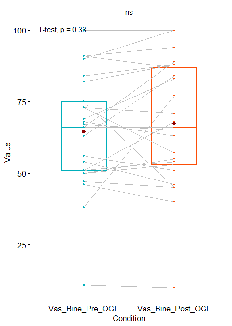

```r
func_t_box(Data_masc, "ID", "Vas_Bine_Pre_ECRAN", "Vas_Bine_Post_ECRAN")       # ns
```

#### 4.3.2.6 Vas_Bine_Pre_ECRAN Vas_Bine_Post_ECRAN

| .y. | group1 | group2 | p | p.adj | p.format | p.signif | method |
| --- | --- | --- | --- | --- | --- | --- | --- |
| value | Vas_Bine_Pre_ECRAN | Vas_Bine_Post_ECRAN | 0.1007605 | 0.1 | 0.1 | ns | T-test |

| estimate | statistic | p.value | parameter | conf.low | conf.high | method | alternative |
| --- | --- | --- | --- | --- | --- | --- | --- |
| -2.44 | -1.706836 | 0.1007605 | 24 | -5.390437 | 0.5104367 | Paired t-test | two.sided |

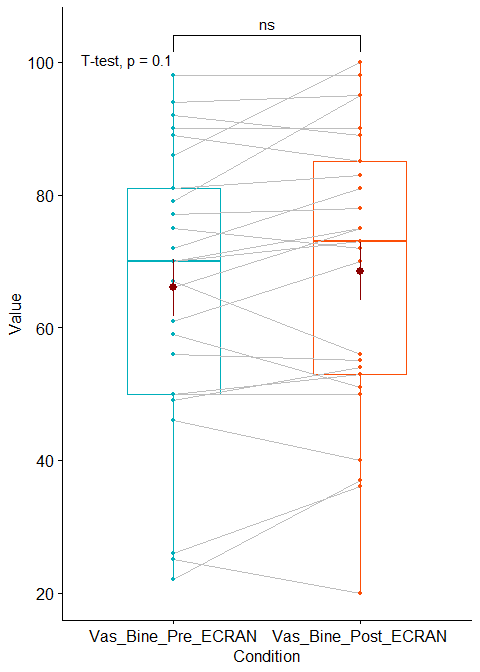

```r
func_t_box(Data_masc, "ID", "IOS_Pre_OGL", "IOS_Post_OGL")                     # sig
```

#### 4.3.2.7 IOS_Pre_OGL IOS_Post_OGL

| .y. | group1 | group2 | p | p.adj | p.format | p.signif | method |
| --- | --- | --- | --- | --- | --- | --- | --- |
| value | IOS_Pre_OGL | IOS_Post_OGL | 0.003335408 | 0.0033 | 0.0033 | ** | T-test |

| estimate | statistic | p.value | parameter | conf.low | conf.high | method | alternative |
| --- | --- | --- | --- | --- | --- | --- | --- |
| -0.92 | -3.258126 | 0.003335408 | 24 | -1.502785 | -0.3372151 | Paired t-test | two.sided |

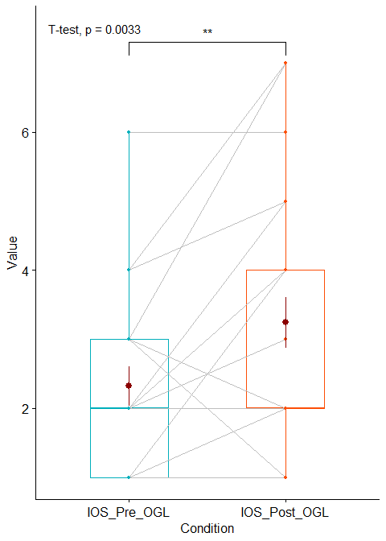

```r
func_t_box(Data_masc, "ID", "IOS_Pre_ECRAN", "IOS_Post_ECRAN")                 # ns
```

#### 4.3.2.8 IOS_Pre_ECRAN IOS_Post_ECRAN

| .y. | group1 | group2 | p | p.adj | p.format | p.signif | method |
| --- | --- | --- | --- | --- | --- | --- | --- |
| value | IOS_Pre_ECRAN | IOS_Post_ECRAN | 0.4952661 | 0.5 | 0.5 | ns | T-test |

| estimate | statistic | p.value | parameter | conf.low | conf.high | method | alternative |
| --- | --- | --- | --- | --- | --- | --- | --- |
| -0.1111111 | -0.6969321 | 0.4952661 | 17 | -0.4474767 | 0.2252545 | Paired t-test | two.sided |

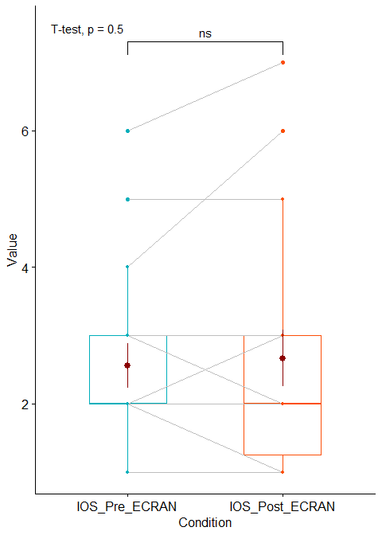

## 4.4 Not considering Cond (OglEcran) - Overall Pre-Post

```r
# Data
vars_OglEcran <- grep("OGL|ECRAN", colnames(Data_merged_wide_all))

Data_notOglEcran <-
  Data_merged_wide_all %>%
  gather(variable, value, vars_OglEcran, -c(ID)) %>%                                      # gather Data and Nr_zi as these are OglEcran level
  tidyr::separate(variable,  c("variable", "OglEcran"), "_(?=[^_]+$)") %>%                # split only on last "_"
  spread(variable, value) %>%
  rename_at(vars(vars_OglEcran), list(~stringr::str_remove_all(., c("_OGL|_ECRAN")))) %>%
  mutate_at(vars(c(45:46, 48:53)), list(~as.numeric(as.character(.)))) %>%
  mutate(Diff_OXT = OXT_Post - OXT_Pre,
         Diff_Vas_Stres = Vas_Stres_Post - Vas_Stres_Pre,
         Diff_Vas_Bine = Vas_Bine_Post - Vas_Bine_Pre
  ) %>%
  arrange(ID)


# Simple before-after analyses with t test Not considering Cond (OglEcran)
Data_notOglEcran %>%
  filter(!ID %in% c(19, 43)) %>%
  func_t_box("ID", "OXT_Pre", "OXT_Post")    # ns
```

#### 4.4.0.1 OXT_Pre OXT_Post

| .y. | group1 | group2 | p | p.adj | p.format | p.signif | method |
| --- | --- | --- | --- | --- | --- | --- | --- |
| value | OXT_Pre | OXT_Post | 0.09758363 | 0.098 | 0.098 | ns | T-test |

| estimate | statistic | p.value | parameter | conf.low | conf.high | method | alternative |
| --- | --- | --- | --- | --- | --- | --- | --- |
| -0.05253542 | -1.672498 | 0.09758363 | 99 | -0.1148623 | 0.009791498 | Paired t-test | two.sided |

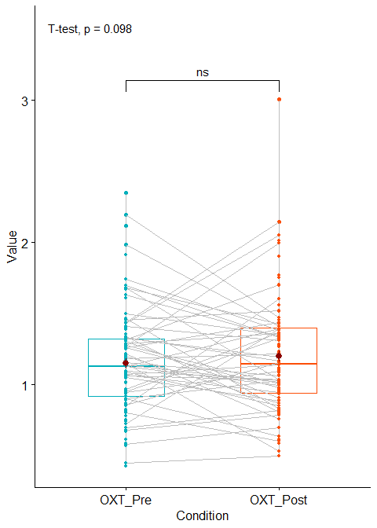

```r
func_t_box(Data_notOglEcran, "ID", "Vas_Stres_Pre", "Vas_Stres_Post")         # sig
```

#### 4.4.0.2 Vas_Stres_Pre Vas_Stres_Post

| .y. | group1 | group2 | p | p.adj | p.format | p.signif | method |
| --- | --- | --- | --- | --- | --- | --- | --- |
| value | Vas_Stres_Pre | Vas_Stres_Post | 0.00175778 | 0.0018 | 0.0018 | ** | T-test |

| estimate | statistic | p.value | parameter | conf.low | conf.high | method | alternative |
| --- | --- | --- | --- | --- | --- | --- | --- |
| 3.19469 | 3.205381 | 0.00175778 | 112 | 1.219927 | 5.169454 | Paired t-test | two.sided |

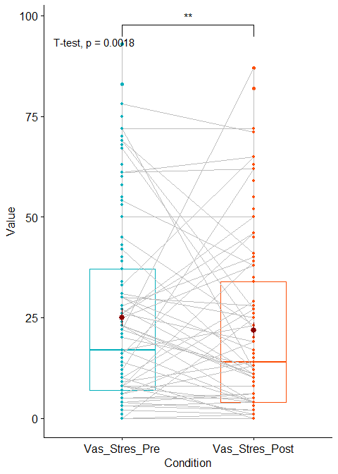

```r
func_t_box(Data_notOglEcran, "ID", "Vas_Bine_Pre", "Vas_Bine_Post")           # sig
```

#### 4.4.0.3 Vas_Bine_Pre Vas_Bine_Post

| .y. | group1 | group2 | p | p.adj | p.format | p.signif | method |
| --- | --- | --- | --- | --- | --- | --- | --- |
| value | Vas_Bine_Pre | Vas_Bine_Post | 0.01984916 | 0.02 | 0.02 | * | T-test |

| estimate | statistic | p.value | parameter | conf.low | conf.high | method | alternative |
| --- | --- | --- | --- | --- | --- | --- | --- |
| -2.513274 | -2.363055 | 0.01984916 | 112 | -4.620602 | -0.4059466 | Paired t-test | two.sided |

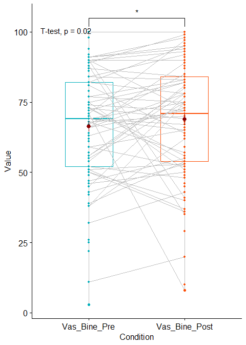

```r
func_t_box(Data_notOglEcran, "ID", "IOS_Pre", "IOS_Post")                     # sig
```

#### 4.4.0.4 IOS_Pre IOS_Post

| .y. | group1 | group2 | p | p.adj | p.format | p.signif | method |
| --- | --- | --- | --- | --- | --- | --- | --- |
| value | IOS_Pre | IOS_Post | 0.000003586081 | 0.0000036 | 0.0000036 | **** | T-test |

| estimate | statistic | p.value | parameter | conf.low | conf.high | method | alternative |
| --- | --- | --- | --- | --- | --- | --- | --- |
| -0.5154639 | -4.919686 | 0.000003586081 | 96 | -0.7234422 | -0.3074856 | Paired t-test | two.sided |

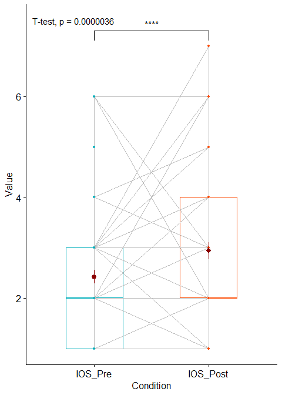

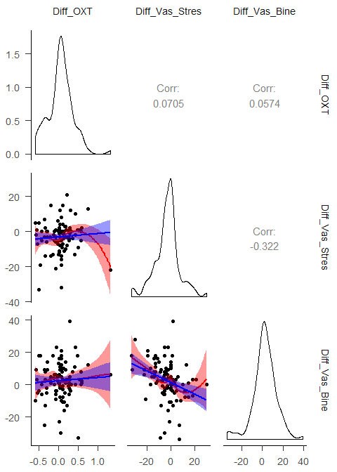

```r
# GGpairs
fn_ggpair_reg <- function(data, mapping, ...){
  p <- ggplot(data = data, mapping = mapping) +
    geom_point() +
    geom_smooth(method=loess, fill="red", color="red", ...) +
    geom_smooth(method=lm, fill="blue", color="blue", ...)
  p
}

GGally::ggpairs(data = Data_notOglEcran %>% filter(!ID %in% c(19, 43)),
                columns = 54:56,
                lower = list(continuous = fn_ggpair_reg))
```

## 4.5 Difference scores conditioned on Anxiety ?

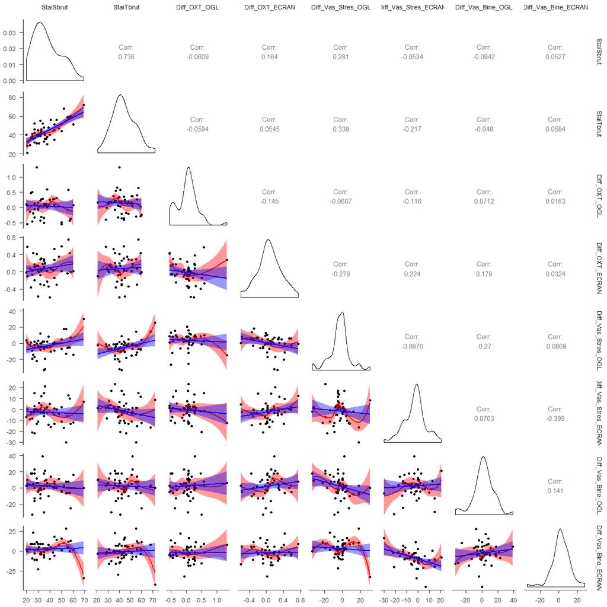

```r
Data_difscores <-
  Data_merged_wide_all %>%
  filter(!ID %in% c(19, 43)) %>%
  mutate(Diff_OXT_OGL = OXT_Post_OGL - OXT_Pre_OGL,
         Diff_OXT_ECRAN = OXT_Post_ECRAN - OXT_Pre_ECRAN,
         Diff_Vas_Stres_OGL = Vas_Stres_Post_OGL - Vas_Stres_Pre_OGL,
         Diff_Vas_Stres_ECRAN = Vas_Stres_Post_ECRAN - Vas_Stres_Pre_ECRAN,
         Diff_Vas_Bine_OGL = Vas_Bine_Post_OGL - Vas_Bine_Pre_OGL,
         Diff_Vas_Bine_ECRAN = Vas_Bine_Post_ECRAN - Vas_Bine_Pre_ECRAN
  )


plot_columns <- match( c("StaiSbrut", "StaiTbrut",
                         "Diff_OXT_OGL", "Diff_OXT_ECRAN",
                         "Diff_Vas_Stres_OGL", "Diff_Vas_Stres_ECRAN",
                         "Diff_Vas_Bine_OGL", "Diff_Vas_Bine_ECRAN"),
                          names(Data_difscores))

# GGpairs
fn_ggpair_reg <- function(data, mapping, ...){
  p <- ggplot(data = data, mapping = mapping) +
    geom_point() +
    geom_smooth(method=loess, fill="red", color="red", ...) +
    geom_smooth(method=lm, fill="blue", color="blue", ...)
  p
}

GGally::ggpairs(data = Data_difscores,
                columns = plot_columns,
                lower = list(continuous = fn_ggpair_reg))
```

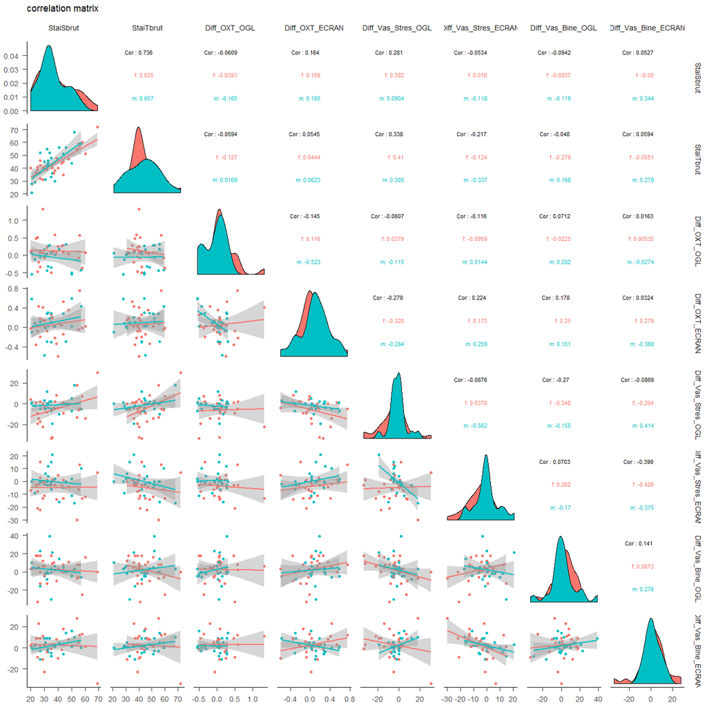

```r
# GGpairs By Gen
GGally::ggpairs(data = Data_difscores,
                columns = plot_columns,
                title = "correlation matrix",
                mapping = aes(colour = Gen),
                lower = list(
                continuous = "smooth",
                combo = "facetdensity",
                mapping = aes(color = Gen)),
                upper = list(continuous = wrap("cor", size = 3, hjust=0.8)))
```

```r
# Coplot Anx
Data_difscores %>%
  filter(!ID %in% c(19, 43)) %>%
    coplot(Diff_OXT_OGL ~ Diff_Vas_Stres_OGL | StaiTbrut,
           data = .,
           rows = 1,
           panel = function(x, y, ...) {
           panel.smooth(x, y, span = .8, iter = 5,...)
           abline(lm(y ~ x), col = "blue")})
```

Missing rows: 9, 20, 26, 30, 38, 47

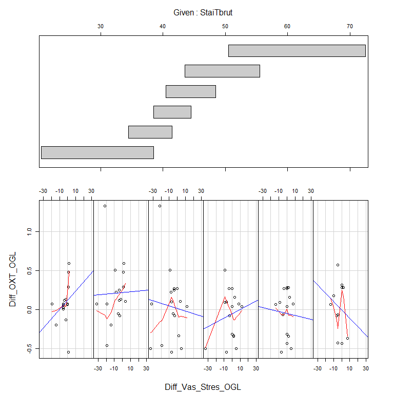

```r
Data_difscores %>%
  filter(!ID %in% c(19, 43)) %>%
    coplot(Diff_OXT_ECRAN ~ Diff_Vas_Stres_ECRAN | StaiTbrut,
           data = .,
           rows = 1,
           panel = function(x, y, ...) {
           panel.smooth(x, y, span = .8, iter = 5,...)
           abline(lm(y ~ x), col = "blue")})
```

Missing rows: 9, 20, 26, 30, 38, 47

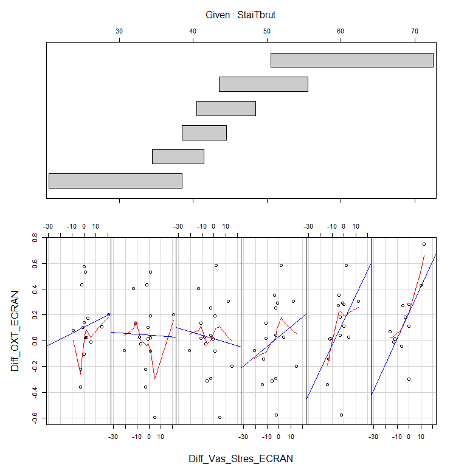

```r
Data_difscores %>%
  filter(!ID %in% c(19, 43)) %>%
  coplot(Diff_OXT_OGL ~ Diff_Vas_Stres_OGL | StaiSbrut,
         data = .,
         rows = 1,
         panel = function(x, y, ...) {
           panel.smooth(x, y, span = .8, iter = 5,...)
           abline(lm(y ~ x), col = "blue")})
```

Missing rows: 9, 20, 26, 30, 38, 47

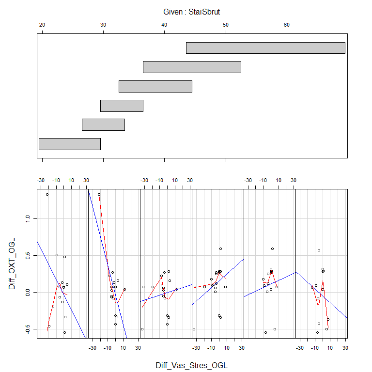

```r
Data_difscores %>%
  filter(!ID %in% c(19, 43)) %>%
  coplot(Diff_OXT_ECRAN ~ Diff_Vas_Stres_ECRAN | StaiSbrut,
         data = .,
         rows = 1,
         panel = function(x, y, ...) {
           panel.smooth(x, y, span = .8, iter = 5,...)
           abline(lm(y ~ x), col = "blue")})
```

Missing rows: 9, 20, 26, 30, 38, 47

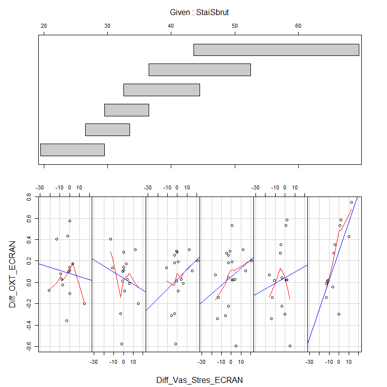

## 4.6 Difference scores conditioned on Extraversion ?

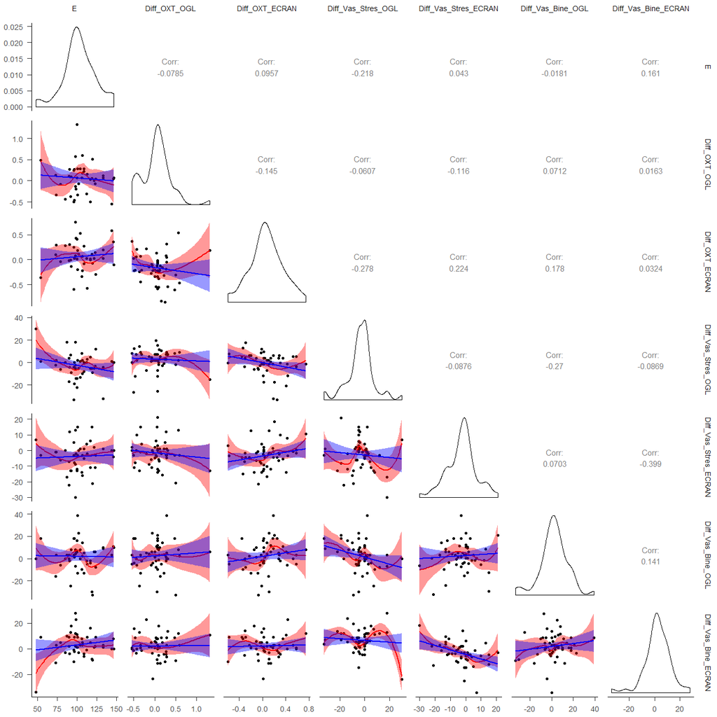

```r
Data_difscores <-
  Data_merged_wide_all %>%
  filter(!ID %in% c(19, 43)) %>%
  mutate(Diff_OXT_OGL = OXT_Post_OGL - OXT_Pre_OGL,
         Diff_OXT_ECRAN = OXT_Post_ECRAN - OXT_Pre_ECRAN,
         Diff_Vas_Stres_OGL = Vas_Stres_Post_OGL - Vas_Stres_Pre_OGL,
         Diff_Vas_Stres_ECRAN = Vas_Stres_Post_ECRAN - Vas_Stres_Pre_ECRAN,
         Diff_Vas_Bine_OGL = Vas_Bine_Post_OGL - Vas_Bine_Pre_OGL,
         Diff_Vas_Bine_ECRAN = Vas_Bine_Post_ECRAN - Vas_Bine_Pre_ECRAN
  )


plot_columns <- match(c("E",
                        "Diff_OXT_OGL", "Diff_OXT_ECRAN",
                        "Diff_Vas_Stres_OGL", "Diff_Vas_Stres_ECRAN",
                        "Diff_Vas_Bine_OGL", "Diff_Vas_Bine_ECRAN"),
                        names(Data_difscores))

# GGpairs
fn_ggpair_reg <- function(data, mapping, ...){
  p <- ggplot(data = data, mapping = mapping) +
    geom_point() +
    geom_smooth(method=loess, fill="red", color="red", ...) +
    geom_smooth(method=lm, fill="blue", color="blue", ...)
  p
}

GGally::ggpairs(data = Data_difscores,
                columns = plot_columns,
                lower = list(continuous = fn_ggpair_reg))
```

## 4.7 Moderation Analysis ()

```r
## Define Function
func_moderation <- function(Data, dep, mod, pred){
  moderation <-
    Data %>%
    medmod::mod(., dep = dep, mod = mod, pred = pred,
                ci = TRUE, estMethod = 'standard', test = TRUE, simpleSlopeEst = FALSE, simpleSlopePlot = TRUE)

  cat(paste("<b> Moderation: ", "Dep = ", dep, "Pred = ", pred, "Mod = ", mod, "</b>"))
  moderation$mod %>%
    knitr::kable(caption = "Moderation", digits = 3) %>%
    print()
  moderation$simpleSlope$plot %>%
    print()
}


Data_merged_wide_all %>%
  filter(!ID %in% c(19, 43)) %>%
  func_moderation(Data = ., dep = "OXT_Post_OGL", mod = "E", pred = "OXT_Pre_OGL")
```

**Moderation: Dep = OXT_Post_OGL Pred = OXT_Pre_OGL Mod = E**

| term | est | se | lower | upper | z | p |
| --- | --- | --- | --- | --- | --- | --- |
| OXT_Pre_OGL | 0.838 | 0.157 | 0.531 | 1.146 | 5.343 | 0.000 |
| E | -0.003 | 0.003 | -0.009 | 0.002 | -1.216 | 0.224 |
| OXT_Pre_OGL:E | -0.012 | 0.011 | -0.034 | 0.010 | -1.050 | 0.294 |

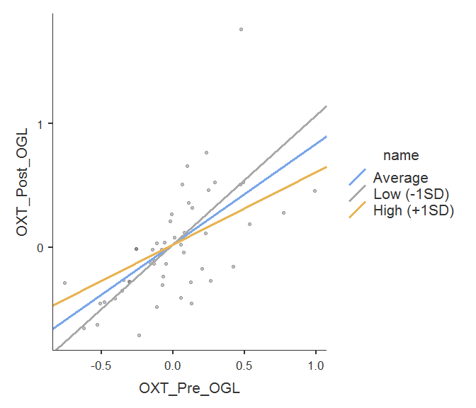

```r
Data_merged_wide_all %>%
  filter(!ID %in% c(19, 43)) %>%
  func_moderation(Data = ., dep = "OXT_Post_ECRAN", mod = "E", pred = "OXT_Pre_ECRAN")
```

**Moderation: Dep = OXT_Post_ECRAN Pred = OXT_Pre_ECRAN Mod = E**

| term | est | se | lower | upper | z | p |
| --- | --- | --- | --- | --- | --- | --- |
| OXT_Pre_ECRAN | 0.742 | 0.103 | 0.539 | 0.944 | 7.169 | 0.000 |
| E | 0.000 | 0.002 | -0.004 | 0.004 | -0.054 | 0.957 |
| OXT_Pre_ECRAN:E | 0.001 | 0.004 | -0.006 | 0.008 | 0.377 | 0.706 |

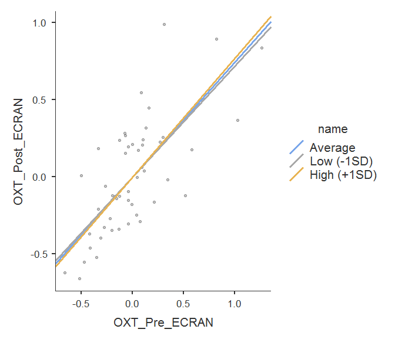

```r
cat("### ANCOVA - Extraversion")
```

### 4.7.1 ANCOVA - Extraversion

```r
df_ancova_e <-
  Data_merged_wide_all %>%
  select("ID", "OXT_Pre_OGL", "OXT_Post_OGL", "OXT_Pre_ECRAN", "OXT_Post_ECRAN", "E") %>%
  tidyr::drop_na() %>%
  gather("OXT_Pre_OGL", "OXT_Post_OGL", "OXT_Pre_ECRAN", "OXT_Post_ECRAN", key = "Cond", value = "value") %>%
  mutate(PrePost = case_when(stringr::str_detect(.$"Cond", "Pre") ~ "Pre",
                             stringr::str_detect(.$"Cond", "Post") ~ "Post",
                             TRUE ~ NA_character_),
         OglEcran = case_when(stringr::str_detect(.$"Cond", "OGL") ~ "OGL",
                              stringr::str_detect(.$"Cond", "ECRAN") ~ "ECRAN",
                              TRUE ~ NA_character_)) %>%
  mutate(PrePost = as.factor(PrePost),
         OglEcran = as.factor(OglEcran)) %>%
  select(-"Cond") %>%
  spread("PrePost", "value")


jmv::ancova(
    formula = Post ~ Pre + OglEcran + E,
    data = df_ancova_e,
    homo = TRUE,
    ss = "3",
    postHoc = ~ OglEcran,
    postHocCorr = list("tukey"),
    effectSize = list("eta", "partEta")
  )
```

ANCOVA

ANCOVA - Post  
──────────────────────────────────────────────────────────────────────────────────────────── Sum of Squares df Mean Square F p η² η²p  
──────────────────────────────────────────────────────────────────────────────────────────── Pre 1568.800 1 1568.800 1324.590 < .001 0.940 0.943  
OglEcran 0.764 1 0.764 0.645 0.424 0.000 0.008  
E 4.891 1 4.891 4.130 0.045 0.003 0.049  
Residuals 94.749 80 1.184  
────────────────────────────────────────────────────────────────────────────────────────────

ASSUMPTION CHECKS

Homogeneity of Variances (Levene’s) ─────────────────────────────────── F df1 df2 p  
─────────────────────────────────── 3.10 1 82 0.082  
───────────────────────────────────

POST HOC TESTS

Post Hoc Comparisons - OglEcran  
───────────────────────────────────────────────────────────────────────────────────── OglEcran OglEcran Mean Difference SE df t p-tukey  
───────────────────────────────────────────────────────────────────────────────────── ECRAN - OGL 0.193 0.240 80.0 0.803 0.424  
─────────────────────────────────────────────────────────────────────────────────────

```r
## Define Function
func_moderation <- function(Data, dep, mod, pred){
  moderation <-
    Data %>%
      medmod::mod(., dep = dep, mod = mod, pred = pred,
                  ci = TRUE, estMethod = 'standard', test = TRUE, simpleSlopeEst = FALSE, simpleSlopePlot = TRUE)

  cat(paste("<b> Moderation: ", "Dep = ", dep, "Pred = ", pred, "Mod = ", mod, "</b>"))
  moderation$mod %>%
    knitr::kable(caption = "Moderation", digits = 3) %>%
    print()
  moderation$simpleSlope$plot %>%
    print()
}

## Apply Function
Data_merged_wide_all %>%
  filter(!ID %in% c(19, 43)) %>%
  func_moderation(Data = ., dep = "OXT_Post_OGL", mod = "StaiTbrut", pred = "OXT_Pre_OGL")

Data_merged_wide_all %>%
  filter(!ID %in% c(19, 43)) %>%
  func_moderation(Data = ., dep = "OXT_Post_ECRAN", mod = "StaiTbrut", pred = "OXT_Pre_ECRAN")





# bla <-
#   Data_merged %>%
#   mutate(Conditie = as.numeric(as.factor(Conditie)))
#
# psych::mediate(data = bla, Oxitocina_post ~ Oxitocina_pre + Conditie + Vas_rel_global)   # moderation with covariate and diagram
```

[output not shown]

## 4.8 Mixed Design ANOVA

```r
# Data
Data_mixedanova <-
  Data_merged_long_all %>%
  mutate(PrePost = case_when(stringr::str_detect(.$"PrePost", "Pre") ~ as.integer(0),
                             stringr::str_detect(.$"PrePost", "Post") ~ as.integer(1),
                             TRUE ~ NA_integer_)) %>%
  mutate(OglEcran = case_when(stringr::str_detect(.$"OglEcran", "ECRAN") ~ as.integer(0),
                           stringr::str_detect(.$"OglEcran", "OGL") ~ as.integer(1),
                           TRUE ~ NA_integer_)) %>%
  mutate(StaiTbrut_dih = sjmisc::dicho(.$"StaiTbrut",
                                       dich.by = "median", as.num = FALSE,                                # similar to Hmisc::cut2, but uses median
                                       val.labels = c("lower", "higher"), append = FALSE)) %>%
  select(ID, OglEcran, PrePost, OXT, StaiTbrut_dih) %>%
  drop_na()


# Mixed Design Anova  # http://www.cookbook-r.com/Statistical_analysis/ANOVA/
aov_mixed1 <- aov(OXT ~ OglEcran * PrePost * StaiTbrut_dih + Error(ID/PrePost), data = Data_mixedanova)
broom::tidy(aov_mixed1)
```

| stratum | term | df | sumsq | meansq | statistic | p.value |
| --- | --- | --- | --- | --- | --- | --- |
| ID | StaiTbrut_dih | 1 | 7.225859 | 7.225859 | 0.5156599 | 0.4761090 |
| ID | Residuals | 49 | 686.629063 | 14.012838 | NA | NA |
| ID:PrePost | PrePost | 1 | 4.157227 | 4.157227 | 0.8840962 | 0.3516946 |
| ID:PrePost | PrePost:StaiTbrut_dih | 1 | 5.859289 | 5.859289 | 1.2460652 | 0.2697496 |
| ID:PrePost | Residuals | 49 | 230.409446 | 4.702234 | NA | NA |
| Within | OglEcran | 1 | 23.029727 | 23.029727 | 2.4996704 | 0.1170924 |
| Within | OglEcran:PrePost | 1 | 2.188589 | 2.188589 | 0.2375517 | 0.6270685 |
| Within | OglEcran:StaiTbrut_dih | 1 | 8.884403 | 8.884403 | 0.9643223 | 0.3285184 |
| Within | OglEcran:PrePost:StaiTbrut_dih | 1 | 7.330299 | 7.330299 | 0.7956383 | 0.3745856 |
| Within | Residuals | 98 | 902.884322 | 9.213105 | NA | NA |

```r
# summary(aov_mixed1)
# model.tables(aov_mixed1, "means")   # is data balanced?




# library(jtools)
# mod1 <- lm(OXT_Post_OGL ~ OXT_Pre_OGL * StaiTbrut, data = Data_mixedanova)
# jtools::summ(mod1)
# jtools::interact_plot(mod1, pred = OXT_Pre_OG, modx = StaiTbrut)
#
# library(interactions)
```

## 4.9 Correlations between Diff_OXT_OGL with other variables (Nothing)

```r
## Correlations between Diffrence Scores with other variables
Correlations_With_One(Data_difscores[,-c(1:2, 5:24)], variable = "Diff_OXT_OGL", correlation_abs_threshold = 0.2, pvalue_threshold = 0.05)  # nothing
```

#### 4.9.0.1 Correlations with Diff_OXT_OGL

| Variable | correlation | p.value | p.signif |
| --- | --- | --- | --- |

Warning in `[<-.data.frame`(`*tmp*`, is_list, value = list(`4` = “<>”)) : replacement element 1 has 1 row to replace 0 rows

## 4.10 Correlations with Oxy

```r
## Mining Correlations with Oxy

# df_OxyAll_cor <-
#   Get_Top_Relationships(Data[,-c(1:7)], correlation_abs_threshold = 0.2, pvalue_threshold = 0.05) %>%
#     dplyr::as_tibble() %>%
#     dplyr::filter_all(any_vars(grepl("Ox", .)))                           # only Oxy, but both Pre and Post Oxy
#
# df_OxyAll_cor %>%
#     print(n = Inf)
# df_OxyAll_cor %>%
#   func_dotplot_cor()
#
# # Correlations only on Pre measures with Oxy -- nothing
# df_OxyPre_cor <-
#   Get_Top_Relationships(Data[,-c(1:7)], correlation_abs_threshold = 0.2, pvalue_threshold = 0.1) %>%
#     dplyr::as_tibble() %>%
#     filter_at(vars(feature_1, feature_2), all_vars(grepl("pre|Pre", .))) %>%
#     dplyr::filter_all(any_vars(grepl("Ox", .)))
```

A work by [Claudiu Papasteri](https://github.com/ClaudiuPapasteri/)

*claudiu.papasteri@gmail.com*